# The impact of earnings expectations on corporate downsizing

Converted from PDF `Schulz-EarningsExpectationsDownsizing-2018-SMJ.pdf` · 12 pages · anchors: page `#pN`, block `#pN-bK`

Page 1

R E S E A R C H A R T I C L E

## The impact of earnings expectations on corporate downsizing

#### Ann-Christine Schulz<sup>1</sup> | Margarethe F. Wiersema<sup>2</sup>

1Research Cluster SMEs and Family Businesses, University of Applied Sciences for Management and Communication (FHWien der WKW), Wien, Austria

2The Paul Merage School of Business, University of California, Irvine, Irvine, California

Correspondence Ann-Christine Schulz, Research Cluster SMEs and Family Businesses, University of Applied Sciences for Management and Communication (FHWien der WKW), Waehringer Guertel 97, 1180 Wien, Austria. Email: ann.schulz@fh-wien.ac.at

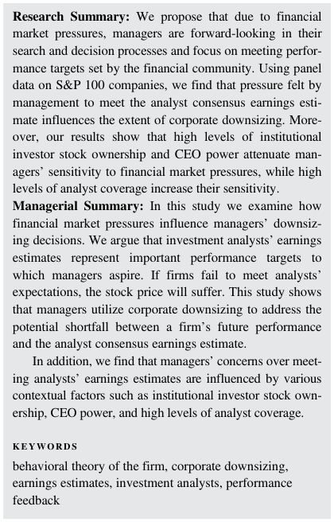

NOTE: figure/graphic rendered as an image from the PDF; its content is not machine-readable text. Caption (if any) follows as the next block.

**text found inside the figure**

Research Summary: We propose that due to financial market pressures, managers are forward-looking in their search and decision processes and focus on meeting performance targets set by the financial community. Using panel data on S&P 100 companies, we find that pressure felt by management to meet the analyst consensus earnings estimate influences the extent of corporate downsizing. Moreover, our results show that high levels of institutional investor stock ownership and CEO power attenuate managers’ sensitivity to financial market pressures, while high levels of analyst coverage increase their sensitivity. Managerial Summary: In this study we examine how financial market pressures influence managers’ downsizing decisions. We argue that investment analysts’ earnings estimates represent important performance targets to which managers aspire. If firms fail to meet analysts’ expectations, the stock price will suffer. This study shows that managers utilize corporate downsizing to address the potential shortfall between a firm’s future performance and the analyst consensus earnings estimate.

In addition, we find that managers’ concerns over meeting analysts’ earnings estimates are influenced by various contextual factors such as institutional investor stock ownership, CEO power, and high levels of analyst coverage.

KEYWORDS

behavioral theory of the firm, corporate downsizing, earnings estimates, investment analysts, performance feedback

1 | INTRODUCTION

Over the past few decades, greater demand for shareholder wealth maximization by institutional investors and other constituents in the financial community have placed increasing pressure on

Received: 28 January 2016 Revised: 6 June 2018 Accepted: 10 June 2018 Published on: 14 August 2018

DOI: 10.1002/smj.2925

Strat Mgmt J. 2018;39:2691–2702. wileyonlinelibrary.com/journal/smj © 2018 John Wiley & Sons, Ltd. 2691

Page 2

managers to meet investment analysts’ earnings estimates (Jensen, 2010). According to a McKinsey study (2013), more than 60% of C-level executives felt that pressure to deliver short-term financial performance goals has increased in recent years. Investment analysts, who issue research reports and earnings estimates for the firm that are disseminated widely to institutional investors, play a key role in shaping investors’ expectations of the firm’s future earnings (Payne & Robb, 2000). When companies fail to deliver on these earnings expectations by having actual earnings that fall below analysts’ estimates, or what is called a “negative earnings surprise,” their stock prices suffer (Kinney, Burgstahler, & Martin, 2002). Not surprisingly, “from corporate boards’ deliberations to financial press reports and internet chats, emphasis is placed on whether a firm meets its earnings forecasts” (Bartov, Givoly, & Hayn, 2002, p. 174).

From prior research, we know that “because executives believe that hitting earnings benchmarks builds credibility with the market,” the analyst consensus earnings estimate<sup>1</sup> represents an important performance target for managers (Graham, Harvey, & Rajgopal, 2005). Managers are highly aware of investment analysts’ earnings estimates and attuned to meeting them because failure to meet these performance targets can have significant adverse consequences on investors’ assessments of the firm and influence managers’ reputations and careers (Graham et al., 2005, p. 5).

According to the behavioral theory of the firm, managers use performance targets as aspirational levels by which to gauge whether organizational or strategic change is necessary (Cyert & March, 1963). One of the most important aspirational levels of performance for managers is the analyst consensus earnings estimate, which differs significantly from other performance benchmarks in that it represents a forward-looking rather than backward-looking aspirational level of firm performance. While prior research has focused on understanding what managers do in response to past poor performance (Brauer & Wiersema, 2018), in this study we investigate the influence of a gap between the firm’s future performance and the analyst consensus earnings estimate on corporate downsizing decisions. This gap in future performance has been termed “earnings pressure” because of the pressure it places on managers to seek to improve earnings in order to meet performance targets (Matsumoto, 2002). To investigate such influence, we examine the extent to which managers utilize corporate downsizing to address a potential performance gap. Corporate downsizing constitutes a major strategic decision. It is used by managers to reduce a firm’s cost structure and improve operational efficiency, and thus to increase a firm’s future performance (Datta, Guthrie, Basuil, & Pandey, 2010). In addition, we examine how different contextual factors may either insulate or make managers more susceptible to the potential adverse consequences of failing to meet earnings expectations and thus lessen or increase the extent to which managers will undertake corporate downsizing in response to earnings pressure. We propose that high levels of institutional investor stock ownership and CEO power may attenuate managers’ sensitivity and concern over meeting these important performance targets, while high levels of analyst coverage and poor financial conditions may increase managers’ sensitivity to earnings pressure.

Our study on the impact of earnings pressure on corporate downsizing makes a significant contribution to the strategy literature by extending our knowledge on the influence of investment analysts on corporate decision-making. Prior research has shown that managers primarily utilize accounting techniques in order to meet the analyst consensus earnings estimate (Payne & Robb, 2000), while Zhang and Gimeno (2016) find that earnings pressure reduces competitive aggressiveness in the airline industry. Our article provides greater insight into the influence that investment analysts have on companies by investigating the impact of earnings pressure on corporate downsizing, a major strategic decision that can occur across industries. In addition, we examine how firm-specific factors can

1The analyst consensus earnings estimate is the average estimated earnings per share estimate of the analysts providing coverage for the firm and has been used as a “proxy”’ for what investors assume will be the firm's performance.

2692 SCHULZ AND WIERSEMA

Page 3

either attenuate or increase managers’ concern over how investors will assess a performance shortfall. Our study thus extends prior work (Zhang & Gimeno, 2016) that has focused on the temporal orientations of managers. Finally, our study also expands our knowledge of the factors that motivate corporate downsizing. By providing evidence that downsizing is undertaken in order to meet analysts’ earnings estimates, our findings differ significantly from prior research that has found that downsizing occurs as a result of poor performance (Ahmadjian & Robinson, 2001; Alakent & Lee, 2010). By finding that, regardless of financial performance, firms utilize downsizing in order to meet analysts’ earnings estimates, we extend our understanding of the role of the financial markets, and specifically earnings pressure, on corporate downsizing decisions.

2 | THEORY AND HYPOTHESES

2.1 | Earnings estimates and corporate downsizing

According to the behavioral theory of the firm, organizational decisions and actions are regarded as responses to performance feedback (Cyert & March, 1963). If firm performance falls short of its aspirational level, managers search for potential solutions and undertake actions to address the performance gap (Cyert & March, 1963). Indeed, a large body of empirical research in management has shown that managers respond by increasing R&D expenditures (Chen, 2008; Chen & Miller, 2007; O’Brien & David, 2014), undertaking acquisitions (Iyer & Miller, 2008) or strategic alliances (Baum, Rowley, Shipilov, & Chuang, 2005; Tyler & Caner, 2015), entering new markets (Greve, 1998), and making long-term investments (Audia & Greve, 2006) when their firms face a performance shortfall.

When considering the influence of performance feedback on managerial choices, Gavetti and Levinthal (2002) distinguish between a backward-looking versus a forward-looking perspective. While a “backward-looking logic” (2002, p. 113) is based on prior experience and past performance feedback, a “forward-looking logic” is derived from “beliefs about the linkage between the choice of actions and the subsequent impact of those actions on outcomes” in the future (2002, p. 133). In an environment in which investors are sensitive to whether firms meet, beat, or miss the analyst consensus earnings estimate, managers are likely to have a forward-looking perspective.

Press coverage of firms’ earnings announcements routinely report firms’ current earnings, with a comparison to the analyst consensus earnings estimate (Bushee, Core, Guay, & Hamm, 2010). Research has shown that there is a “reward to meeting or beating analysts’ earnings estimates and a penalty for failing to do so” (Bartov et al., 2002, p. 175). Even missing the analyst consensus earnings estimate by a small amount can have significant consequences for a firm’s stock, as illustrated by the following example:

The natural foods supermarket chain was hit hard by investors who were less-than-excited by the company's results. Unfortunately, Whole Foods reported an earnings miss for the first quarter and reduced its guidance for 2014. Wall Street expected the company to report a Q1 EPS of $0.44, but Whole Foods could only muster $0.42. In afterhours trading, Whole Foods is currently down more than 5%. (Yahoo Finance, February 12, 2014)

Because of their high visibility and potential influence on investors and the broader public, investment analysts are widely monitored by managers, and their earnings estimates represent important performance targets (Graham et al., 2005).<sup>2</sup> Managers are highly aware of and attuned to meeting

2While investment analysts are important intermediaries in the financial markets who write research reports and issue earnings estimates for the firms they cover, they do not provide advice to the firm's executives on how to manage the firm (Groysberg & Healy, 2013).

SCHULZ AND WIERSEMA 2693

Page 4

analysts’ earnings estimates in large part because they are concerned about their own reputations and careers. Moreover, stock option pay represents the majority of executive compensation in publicly listed firms. Consequently, only 35% of firms miss their analysts’ consensus earnings estimate (Bartov & Cohen, 2009).

Brauer and Wiersema (2018) note that despite considerable research attention in finance and accounting on the phenomenon of earnings management, there are only a few studies in management that have examined how the pressure to meet the analysts’ consensus earnings estimate influences managerial decisions. Zhang and Gimeno (2010) find no direct relationship between earnings pressure and competitive behavior in the electricity industry, but do find that firms operating in markets where they possess greater market share restrict their capacity utilization when faced with earnings pressure. In another study examining the airline industry, Zhang and Gimeno (2016) find that firms facing earnings pressure reduce their competitive aggressiveness. While providing evidence that managers undertake real actions in response to earnings pressure, both studies’ findings are limited to short-term output and pricing decisions within single-industry settings. In this study, we seek to more broadly understand the importance of analyst consensus earnings estimates for firms by examining whether earnings pressure influences strategic decision-making across industries.

We propose that when a firm faces a performance shortfall as reflected by earnings pressure, managers will utilize corporate downsizing in order to reduce the firm’s fixed costs and improve its earnings. Corporate downsizing, a prevalent management practice, refers to a permanent reduction in the firm’s workforce with the aim to cut a firm’s costs and improve its overall performance (Budros, 1999; Freeman & Cameron, 1993). It constitutes a major strategic decision that not only affects firm size but usually comes with changes in the firm’s structure and operations (Datta et al., 2010). Furthermore, we expect that the greater the earnings pressure faced by management, the more extensive the downsizing.

Hypothesis 1 (H1) Earnings pressure will be positively related to the extent of corporate downsizing.

2.2 | The impact of firm-specific factors on managers’ sensitivity to earnings pressure

Missing analysts’ earnings targets can have severe consequences for the reputation of the firm and its management and may increase investors’ uncertainty regarding the future performance of the firm, with subsequent effects on the firm’s stock price (Kinney et al., 2002). However, the extent of managers’ sensitivity and concern over how investors will perceive a performance shortfall is likely to vary depending on contextual factors that either insulate managers or make them more susceptible to the adverse consequences of missing these important performance targets.

Specifically, we propose that both institutional investor stock ownership and CEO power may insulate managers from the adverse consequences of missing analysts’ earnings estimates and thus lessen managers’ sensitivity to responding to earnings pressure. Institutional investors such as mutual funds, pension funds, or insurance companies are important and sophisticated investors of the firm (Bushee, 1998). They are committed to a long-term investment outlook and are less likely to sell their shareholdings if the firm faces a short-term performance shortfall. Prior research has shown that firms with higher levels of institutional investor stock ownership are less likely to cut R&D expenses in order to meet short-term earnings goals (Bushee, 1998), and are less likely to utilize accounting accruals to address a potential performance gap (Chung, Firth, & Kim, 2002). Zhang and Gimeno (2016) found that firms with dedicated institutional investors are also less likely to respond to

2694 SCHULZ AND WIERSEMA

Page 5

earnings pressure in the airline industry. Thus, greater institutional investor stock ownership can reduce management’s sensitivity to shortfalls in short-term performance. Similarly, we argue that CEOs with greater power are less likely to suffer from the adverse consequences of missing performance targets, as they have been shown to be less likely to be dismissed for poor performance (Zhang, 2008). As a result, we propose that higher levels of institutional investor stock ownership as well as greater CEO power may attenuate managers’ sensitivity and concern over meeting the analysts’ consensus earnings estimate and thus lessen the effect of earnings pressure on the extent of corporate downsizing.

Hypothesis 2 (H2) Greater institutional investor stock ownership lessens the effect of earnings pressure on the extent of corporate downsizing.

Hypothesis 3 (H3) Greater CEO power lessens the effect of earnings pressure on the extent of corporate downsizing.

On the other hand, we suggest that both the extent of analyst coverage and poor financial conditions make managers more susceptible to the adverse consequences of missing analysts’ earnings estimates and thus heighten managers’ sensitivity to responding to earnings pressure. While the majority of publicly traded firms have analyst coverage, the number of analysts that cover a firm varies considerably (Bhushan, 1989). Extensive analyst coverage creates visibility and attracts investors due to wider dissemination and awareness of analysts’ earnings estimates within the investment community (Merton, 1987). Firms with extensive analyst coverage draw not only greater investor attention, but also more scrutiny that is likely to affect managements’ sensitivity to analysts’ earnings expectations. He and Tian (2013, p. 187), for example, find that high levels of analyst coverage have a detrimental effect on managers by “creating excessive pressure on managers and exacerbating managerial myopia.” Similarly, firms with poor financial conditions face greater scrutiny by investors and shareholder activists who seek to discipline poorly performing managers (Shleifer & Vishny, 1986). Moreover, poor firm performance is a major predictor of CEO dismissal (Wiersema & Zhang, 2011). As a result, we propose that high levels of analyst coverage and less favorable firm financial conditions may increase managers’ sensitivity and concern over meeting the analysts’ consensus earnings estimate and thus strengthen the effect of earnings pressure on the extent of corporate downsizing.

Hypothesis 4 (H4) High levels of firm analyst coverage strengthen the effect of earnings pressure on the extent of corporate downsizing.

Hypothesis 5 (H5) Less favorable firm financial conditions strengthen the effect of earnings pressure on the extent of corporate downsizing.

3 | METHODS

3.1 | Sample

We utilize the S&P 100 firms for the period 1993–2000, a time period in which downsizing activity was both highly pervasive (1993–1994) as well as less frequent (1999 and 2000). The unit of analysis is a firm-year. Due to missing data and mergers and acquisitions, the final sample comprises 92 firms with 653 firm-year observations. The explanatory and control variables are derived from the

SCHULZ AND WIERSEMA 2695

Page 6

Compustat, CRSP, ExecuComp, Institutional Brokers Estimate System (I/B/E/S), and Thomson Reuters 13f databases.

3.2 | Dependent variable: Extent of corporate downsizing

We measure the extent of corporate downsizing as the percentage of a firm’s employees that are announced to be laid off in a given firm-year t (number of employees laid off divided by a firm’s total number of employees). We identify downsizing announcements of considerable size (at least 1% of employees). The final panel dataset of 653 firm-years consists of 167 firm-years with downsizing and 486 firm-years with no downsizing announcements.

3.3 | Explanatory variables

3.3.1 | Earnings pressure

Earnings pressure is calculated using a measure developed by Matsumoto (2002). The measure is defined as the difference between the analyst consensus estimate for the earnings per share (EPS) of the firm in year t, measured at the beginning of year t, and the potential EPS for the firm in year t. The difference is then divided by the stock price for the firm at the end of year t–1. The variable is winsorized at the 10% level and has a mean and median of 0.01, similar to that of Zhang and Gimeno (2010).

3.3.2 | Institutional investor stock ownership We measure institutional investor (II) stock ownership as the percentage of a firm’s shareholdings owned by institutional investors in year t-1.

3.3.3 | CEO power

We use three measures of CEO power: CEO tenure, CEO duality, and CEO stock ownership<sup>3</sup> in year t-1.

3.3.4 | High analyst coverage

High analyst coverage is measured as a dummy variable with a value of “1” if the firm is covered by at least 30 analysts (mean of the sample plus one standard deviation) and a value of “0” otherwise.

3.3.5 | Firm financial condition We use three measures for a firm’s financial condition: Tobin’s Q, change in industry-adjusted ROA, and change in sales in year t-1.

3.4 | Control variables

In order to account for alternative factors that may influence the extent of corporate downsizing, we control for firm age, firm size, liquidity, leverage, labor productivity, firm loss years, firm performance, increase in EPS, quarterly earnings miss, manufacturing firms, and year dummy variables.

3We collected data on CEO stock ownership from the Edgar database. Data on CEO stock ownership was only available for 535 firmyears. We examined both CEO shareholdings of common stock as well as their beneficial ownership, which includes stock options exercisable within 60 days. The results were the same.

2696 SCHULZ AND WIERSEMA

Page 7

4 | RESULTS

To analyze the influence of earnings pressure on the extent of corporate downsizing we use a random effects Tobit model. Table 1 presents the results of the regression analyses.<sup>4</sup> Table 2 shows values of the total marginal effect of earnings pressure on the extent of corporate downsizing at different levels of the moderating variables.

In Table 1 our models to analyze the hypotheses indicate strong significance of each model over the simple model that includes only a constant. As shown in Model 1, earnings pressure is significant and positively related (β = 0.66; p = .00) to the extent of corporate downsizing, as predicted. An examination of the marginal effect of earnings pressure on the extent of downsizing over all values of the model variables is, as expected, positive and significant (β = 0.16; p = .00). These findings support Hypothesis 1 that earnings pressure will be positively related to the extent of corporate downsizing. In terms of the actual impact that earnings pressure has on the extent of downsizing, we find that an increase in earnings pressure by one standard deviation results in a 9.6% increase in the extent of corporate downsizing.

In Model 2 in Table 1, we test the moderating hypothesis (H2) that greater institutional investor stock ownership lessens the effect of earnings pressure on the extent of downsizing. As shown in Model 2, the interaction of earnings pressure with institutional investor stock ownership is negative and significant (β = −2.04; p = .04). As shown in Table 2, the marginal effect of earnings pressure on the extent of downsizing is as predicted, with earnings pressure having a greater effect on the extent of downsizing at low levels of institutional investor stock ownership (β = 0.24; p = .00) than at mean levels of institutional investor stock ownership (β = 0.16; p = .00). For firms with high levels of institutional investor stock ownership (74%), the effect of earnings pressure on downsizing is marginally significant (β = 0.09; p = .09). These results suggest support for Hypothesis 2 that greater institutional investor stock ownership lessens the effect of earnings pressure on the extent of corporate downsizing.

To test the moderating hypothesis (H3) that greater CEO power lessens the effect of earnings pressure on the extent of downsizing, we examine the impact of CEO tenure, CEO duality, and CEO stock ownership. We analyze CEO tenure and CEO stock ownership separately since these measures are highly correlated (ρ = 0.55). As shown in Model 3a, the interaction of earnings pressure with CEO tenure is negative and significant (β = −0.06; p = .03) and the interaction of earnings pressure with CEO duality is not significant (β = 0.01; p = .99). As shown in Model 3b, the interaction of earnings pressure with CEO stock ownership is negative and significant (β = −0.37; p = .02) and the interaction of earnings pressure with CEO duality is not significant (β = −0.76; p = .21). As shown in Table 2, the marginal effect for CEO tenure is as predicted, with earnings pressure having a greater effect on the extent of corporate downsizing in firms with newly appointed CEOs (β = 0.28; p = .00) than in firms with CEOs that have a mean tenure of 6.8 years (β = 0.16; p = .00). In firms with CEOs with long tenure (13.8 years), the effect of earnings pressure on downsizing is not significant (β = 0.05; p = .35). The marginal effect for CEO stock ownership is as predicted, with earnings pressure having a greater effect on the extent of corporate downsizing in firms with low CEO stock ownership (β = 0.31; p = .00) than in firms with mean levels of CEO stock ownership (β = 0.13; p = .01). In firms with high CEO stock ownership (0.52%), the effect of earnings pressure on downsizing is not significant β = −0.02; p = .77). These results suggest support for Hypothesis 3 that greater CEO power lessens the effect of earnings pressure on the extent of corporate downsizing.

4Descriptive statistics and correlations are available from the authors upon request.

SCHULZ AND WIERSEMA 2697

Page 8

TABLE 1 Tobit analysis for the extent of corporate downsizing<sup>a</sup>

Control Model Model 1 Model 2 Model 3a Model 3b Model 4 Model 5

Intercept −0.357 −0.360 −0.366 −0.307 −0.188 −0.347 −0.342

(0.001) (0.001) (0.001) (0.004) (0.114) (0.001) (0.002)

Firm age 0.005 0.005 0.006 0.000 −0.020 0.003 0.004

(0.838) (0.848) (0.800) (0.992) (0.449) (0.897) (0.857)

Firm size 0.029 0.030 0.028 0.026 0.021 0.027 0.028

(0.000) (0.000) (0.001) (0.001) (0.021) (0.001) (0.001)

Change in sales −0.092 −0.097 −0.093 −0.100 −0.101 −0.085 −0.097

(0.028) (0.016) (0.018) (0.013) (0.026) (0.026) (0.015)

Liquidity 0.096 0.087 0.084 0.082 0.068 0.090 0.085

(0.317) (0.356) (0.368) (0.382) (0.503) (0.312) (0.366)

Leverage −0.092 −0.077 −0.060 −0.080 −0.054 −0.056 −0.076

(0.152) (0.225) (0.348) (0.202) (0.442) (0.372) (0.232)

Labor productivity −0.000 −0.000 −0.000 −0.000 −0.000 −0.000 −0.000

(0.209) (0.328) (0.377) (0.496) (0.660) (0.429) (0.339)

Firm loss years 0.020 0.005 0.006 0.002 0.018 0.009 0.004

(0.081) (0.636) (0.567) (0.855) (0.180) (0.408) (0.754)

Industry-adjusted ROA −0.266 −0.226 −0.208 −0.203 −0.175 −0.212 −0.256

(0.010) (0.026) (0.037) (0.045) (0.103) (0.028) (0.045)

Total stock return −0.036 −0.029 −0.031 −0.020 −0.014 −0.029 −0.022

(0.292) (0.364) (0.331) (0.532) (0.700) (0.352) (0.501)

Increase in EPS −0.042 −0.043 −0.041 −0.042 −0.048 −0.040 −0.045

(0.004) (0.003) (0.004) (0.003) (0.003) (0.003) (0.001)

Manufacturing firm 0.048 0.046 0.044 0.038 0.047 0.051 0.046

(0.008) (0.010) (0.013) (0.031) (0.018) (0.003) (0.010)

Earnings pressure 0.663 0.688 0.649 1.373 0.407 0.629

(0.000) (0.000) (0.191) (0.018) (0.020) (0.000)

II stock ownership −0.017

(0.753)

Earnings pressure × II stock ownership −2.036

(0.038)

CEO tenure −0.003

(0.040)

Earnings pressure × CEO tenure −0.059

(0.027)

CEO duality −0.005 −0.008

(0.817) (0.710)

Earnings pressure × CEO duality 0.007 −0.761

(0.989) (0.212)

CEO stock ownership −0.006

(0.371)

Earnings pressure × CEO stock ownership −0.367

(0.024)

2698 SCHULZ AND WIERSEMA

Page 9

In Model 4 we test the moderating hypothesis (H4) that high levels of firm analyst coverage strengthen the effect of earnings pressure on the extent of downsizing. As shown in Model 4, the interaction of earnings pressure with high analyst coverage is positive and significant (β = 1.22; p = .00). As shown in Table 2, our examination of the marginal effect of earnings pressure on

TABLE 1 (Continued)

Control Model Model 1 Model 2 Model 3a Model 3b Model 4 Model 5

High analyst coverage 0.014

(0.451)

Earnings pressure × high analyst coverage 1.216

(0.001)

Change in industry-adjusted ROA 0.100

(0.439)

Earnings pressure × change in industry-adjusted ROA −4.088

(0.101)

Log-likelihood −63.706 −55.909 −53.518 −50.788 −48.489 −50.216 −54.527

Chi-square statistic<sup>b</sup> 59.400 73.214 78.750 81.169 63.499 87.630 76.558

TABLE 2 Analysis of the total marginal effect of the moderator variables and earnings pressure on the extent of corporate downsizing<sup>a</sup>

Moderator variable

Level of moderator

Value of moderator

Average marginal effect of earnings pressure

Institutional investor stock ownership

Low 0.453 0.239 (0.000)

Mean 0.592 0.161 (0.000)

High 0.744 0.087 (0.093)

CEO tenure<sup>b</sup> Low 0.000 0.280 (0.000)

Mean 6.764 0.158 (0.000)

High 13.775 0.053 (0.348)

CEO stock ownership<sup>c</sup> Low 0.014 0.307 (0.000)

Mean 0.086 0.128 (0.008)

High 0.520 −0.021 (0.774)

High analyst coverage Low 0 0.099 (0.021)

High 1 0.440 (0.000)

n = 653 firm-years (n = 535 for CEO stock ownership); p-values are reported in parentheses. a For the moderators, the low (high) value are one standard deviation below (above) its sample mean. b We took “0” as the low value for the moderator because the value of one standard deviation below the sample mean is negative for

CEO tenure. c The values of the CEO stock ownership variable are in percentage.

SCHULZ AND WIERSEMA 2699

Page 10

corporate downsizing is as predicted, with earnings pressure having a greater effect on the extent of downsizing for firms with high analyst coverage (β = 0.44; p = .00) than for all other firms (β = 0.10; p = .02), suggesting support for Hypothesis 4 that high levels of analyst coverage strengthen the effect of earnings pressure on the extent of corporate downsizing.

To test the moderating hypothesis (H5) that firms with less favorable financial conditions will undertake more downsizing in response to earnings pressure, we examine three measures: Tobin’s Q, change in industry-adjusted return on assets (ROA), and change in sales. However, in Model 5 we report only the results of the interaction term of earnings pressure with change in industry-adjusted ROA (β = −4.09; p = .10). As none of the interactions terms were significant, we do not find support for Hypothesis 5.

To examine the robustness of our findings, we also examined full models with all significant moderating variables, utilized a more recent time period and alternative specifications of earnings pressure, and excluded potential outliers. Overall, these analyses provide evidence for the robustness of our results.<sup>5</sup>

5 | DISCUSSION

Our study sought to provide greater insight into the role of earnings pressure on companies by examining its influence on strategic decision-making. Prior research found that, in the electricity industry, only firms that operate in markets where they possess greater market power respond to earnings pressure by restricting their output (Zhang & Gimeno, 2010), while in the airline industry, firms respond to earnings pressure by reducing their competitive aggressiveness (Zhang & Gimeno, 2016). In this study, we provide evidence that the impact of earnings pressure is not limited to the airline and electricity industries, but extends to firms across a variety of industries. Specifically, managers utilize corporate downsizing, a major strategic decision, to address the potential shortfall between a firm’s future performance and the analysts’ consensus earnings estimate. We also find that the more intense the pressure, the greater the extent of corporate downsizing. Furthermore, our analysis provides evidence that managers’ concerns over how investors will assess a performance shortfall may depend on contextual factors. Specifically, the long-term outlook of institutional investors and the greater discretion of powerful CEOs will insulate management from the potential adverse consequences of missing analysts’ earnings estimates. In contrast, the greater scrutiny that accompanies high levels of analyst coverage will make managers more sensitive to meeting these performance targets. Thus our study extends prior work on earnings pressure that has shown that managers’ response to earning pressure is influenced by their temporal orientation (Zhang & Gimeno, 2016).

Moreover, our study contributes to the emerging literature on the influence of investment analysts on corporate decision-making (see Brauer & Wiersema, 2018, for an overview) by focusing on the importance of the analyst consensus earnings estimates as aspirational levels of performance. In evaluating the firm’s performance, prior studies have predominately relied on historical or social comparisons and have utilized accounting measures of performance or asset and sales growth (Audia & Greve, 2006; Bromiley & Harris, 2014; Greve, 2003; Iyer & Miller, 2008; Kim, Haleblian, & Finkelstein, 2011; Miller & Chen, 2004). Recent research, however, has highlighted that these historical or social performance targets may not necessarily be the most relevant (Moliterno, Beck, Beckman, & Meyer, 2014). Our article expands our conceptualization of what constitutes the aspirational levels by which managers gauge their firm’s performance and that motivate them to address a performance gap.

5Results are available from the authors upon request.

2700 SCHULZ AND WIERSEMA

Page 11

Finally, our study advances our knowledge of the factors that motivate corporate downsizing beyond the product-market focus of prior research. This study’s focus on analysts’ earnings expectations as a driver of corporate downsizing differs significantly from prior research that has examined corporate downsizing as a result of past poor firm performance (Ahmadjian & Robinson, 2001; Alakent & Lee, 2010) or changing economic or industry conditions such as a demand decline, deregulation, or economic downturn (Filatotchev, Buck, & Zhukov, 2000; Vicente-Lorente & Suárez-González, 2007). Other studies have shown that downsizing is associated with restructuring efforts, plant closings, and discontinued operations (Farber & Hallock, 2009; Hillier, Marshall, McColgan, & Werema, 2007). By finding that managers utilize corporate downsizing in order to meet analysts’ earnings estimates, we advance our understanding of the determinants of this important strategic decision. Due to the heightened focus on shareholder wealth maximization and performance targets, even managers of successful companies will use downsizing if they experience earnings pressure. Thus, our study expands our understanding of the factors that can influence corporate downsizing by examining the role of financial market pressures.

ACKNOWLEDGEMENTS

We would like to thank associate editor Jim Westphal and two anonymous reviewers for their constructive comments. We also thank Yu Zhang for providing us with the data for our earnings pressure measure.

REFERENCES

Ahmadjian, C. L., & Robinson, P. (2001). Safety in numbers: Downsizing and the deinstitutionalization of permanent employment in

Japan. Administrative Science Quarterly, 46, 622–654. Alakent, E., & Lee, S.-H. (2010). Do institutionalized traditions matter during crisis? Employee downsizing in Korean manufacturing

organizations. Journal of Management Studies, 47(3), 509–532. Audia, P. G., & Greve, H. (2006). Less likely to fail: Low performance, firm size, and factory expansion in the shipbuilding industry.

Management Science, 52, 83–94. Bartov, E., & Cohen, D. (2009). The ‘numbers game’ in the pre- and post-sarbanes-oxley eras. Journal of Accounting, Auditing and

Finance, 24, 505–534. Bartov, E., Givoly, D., & Hayn, C. (2002). The rewards to meeting or beating earnings expectations. Journal of Accounting and Eco-

nomics, 33, 173–204. Baum, J. A. C., Rowley, T. J., Shipilov, A. V., & Chuang, Y.-T. (2005). Dancing with strangers: Aspiration performance and the

search for underwriting syndicate partners. Administrative Science Quarterly, 50, 536–575. Bhushan, R. (1989). Firm characteristics and analyst following. Journal of Accounting and Economics, 11, 255–274. Brauer, M., & Wiersema, M. (2018). Analyzing analyst research: A review of past coverage and recommendations for future research.

Journal of Management, 44, 218–248. Bromiley, P., & Harris, J. D. (2014). A comparison of alternative measures of organizational aspirations. Strategic Management Jour-

nal, 35, 338–357. Budros, A. (1999). A conceptual framework for analyzing why organizations downsize. Organization Science, 10, 69–82. Bushee, B. J. (1998). The influence of institutional investors on myopic R&D investor behavior. Accounting Review, 73, 305–333. Bushee, B. J., Core, J., Guay, W., & Hamm, S. J. W. (2010). The role of the business press as an information intermediary. Journal of

Accounting Research, 48, 1–19. Chen, W.-R. (2008). Determinants of firms’ backward- and forward looking R&D search behavior. Organization Science, 19,

609–622. Chen, W.-R., & Miller, K. D. (2007). Situational and institutional determinants of firms’ R&D search intensity. Strategic Management

Journal, 28, 369–381. Chung, R., Firth, M., & Kim, J.-B. (2002). Institutional monitoring and opportunistic earnings management. Journal of Corporate

Finance, 8, 29–48. Cyert, R. M., & March, J. G. (1963). A behavioral theory of the firm. Malden, MA: Blackwell. Datta, D. K., Guthrie, J. P., Basuil, D., & Pandey, A. (2010). Causes and effects of employee downsizing: A review and synthesis.

Journal of Management, 36, 281–348.

SCHULZ AND WIERSEMA 2701

Page 12

Farber, H. S., & Hallock, K. F. (2009). The changing relationship between job loss announcements and stock prices: 1970–1999.

Labour Economics, 16, 1–11. Filatotchev, I., Buck, T., & Zhukov, V. (2000). Downsizing in privatized firms in Russia, Ukraine, and Belarus. Academy of Manage-

ment Journal, 43, 286–304. Freeman, S. J., & Cameron, K. F. (1993). Organizational downsizing: A convergence and reorientation framework. Organization Sci-

ence, 4, 10–29. Gavetti, G., & Levinthal, D. (2002). Looking forward and looking backward: Cognitive and experiential search. Administrative Science

Quarterly, 45, 113–137. Graham, J. R., Harvey, C. R., & Rajgopal, S. (2005). The economic implications of corporate financial reporting. Journal of Account-

ing and Economics, 40, 3–73. Greve, H. R. (1998). Performance, aspirations, and risky organizational change. Administrative Science Quarterly, 43, 58–86. Greve, H. R. (2003). Organizational learning from performance feedback: A behavioral perspective on innovation and change.

Cambridge, England: Cambridge University Press. Groysberg, B., & Healy, P. M. (2013). Wall street research: Past, present, and future. Stanford, CA: Stanford University Press. He, J., & Tian, X. (2013). The dark side of analyst coverage: The case of innovation. Journal of Financial Economics, 109, 856–878. Hillier, D., Marshall, A., McColgan, P., & Werema, S. (2007). Employee layoffs, shareholder wealth and firm performance: Evidence

from the UK. Journal of Business Finance and Accounting, 34, 467–494. Iyer, D. N., & Miller, K. D. (2008). Performance feedback, slack, and the timing of acquisitions. Academy of Management Journal,

51(4), 808–822. Jensen, M. C. (2010). The modern industrial revolution, exit, and the failure of internal control systems. Journal of Applied Corporate

Finance, 22, 43–58. Kim, J.-Y., Haleblian, J., & Finkelstein, S. (2011). When firms are desperate to grow via acquisition: The effect of growth patterns and

acquisition experience on acquisition premiums. Administrative Science Quarterly, 56, 26–60. Kinney, W., Burgstahler, D., & Martin, R. (2002). Earnings surprise “materiality” as measured by stock returns. Journal of Accounting

Research, 40, 1297–1329. Matsumoto, D. A. (2002). Management’s incentives to avoid negative earnings surprises. Accounting Review, 77, 483–514. McKinsey. (2013). Short-termism: Insights from business leaders. Focusing Capital on the Long Term (December 26). Merton. (1987). A simple model of capital market equilibrium with incomplete information. Journal of Finance, 42, 483–510. Miller, K. D., & Chen, W.-R. (2004). Organizational risk preferences: Tests of the march-shapira model. Academy of Management

Journal, 47, 105–115. Moliterno, T. P., Beck, N., Beckman, C. M., & Meyer, M. (2014). Knowing your place: Social performance feedback in good times

and bad times. Organization Science, 25, 1684–1702. O’Brien, J. P., & David, P. (2014). Reciprocity and R&D search: Applying the behavioral theory of the firm to a communitarian con-

text. Strategic Management Journal, 35, 550–565. Payne, J. L., & Robb, S. W. G. (2000). Earnings management: The effect of ex-ante earnings expectations. Journal of Accounting,

Auditing, and Finance, 15, 371–392. Shleifer, A., & Vishny, R. W. (1986). Large shareholders and corporate control. Journal of Political Economy, 94, 461–488. Tyler, B. B., & Caner, T. (2015). New product introductions below aspirations, slack and R&D alliances: A behavioral perspective.

Strategic Management Journal, 37, 896–910. Vicente-Lorente, J. D., & Suárez-González, I. (2007). Ownership traits and downsizing behavior: Evidence for the largest Spanish

firms, 1990–1998. Organization Studies, 28, 1613–1638. Wiersema, M. F., & Zhang, Y. (2011). CEO dismissal: The role of investment analysts. Strategic Management Journal, 32,

1161–1182. Zhang, Y. (2008). Information asymmetry and the dismissal of newly appointed CEOs: An empirical investigation. Strategic Manage-

ment Journal, 29(8), 859–872. Zhang, Y., & Gimeno, J. (2010). Earnings pressure and competitive behavior: Evidence from the U.S. electricity industry. Academy of

Management Journal, 53, 743–768. Zhang, Y., & Gimeno, J. (2016). Earnings pressure and long-term corporate governance: Can long-term-oriented investors and man-

agers reduce the quarterly earnings obsession? Organization Science, 27, 354–372.

How to cite this article: Schulz A-C, Wiersema MF. The impact of earnings expectations on corporate downsizing. Strat Mgmt J. 2018;39:2691–2702. https://doi.org/10.1002/smj.2925

2702 SCHULZ AND WIERSEMA